# Classifying Galaxies

The goal of this project is to automatically classify galaxies using a deep neural network, taking in a picture of a galaxy and deciding what category it falls into (disc, round, cigar shape, etc).

The pictures are from the Sloan Digital Sky Survey and the labels from the Galaxy Zoo. We will then write and train a neural network to do this classification.

```python
import numpy as np
import jax.numpy as jnp
from jax import jit
import  jax
import matplotlib.pyplot as plt
import math
from matplotlib.animation import FuncAnimation
import itertools
from IPython.display import HTML
import pickle
import datetime;datetime.datetime.now()
```

Importing the data

```python
import requests

url = "https://courses.physics.illinois.edu/phys246/fa2020/code/dataG.pkl.gz"
filename = "dataG.pkl.gz"

response = requests.get(url, stream=True)
with open(filename, "wb") as file:
    for chunk in response.iter_content(chunk_size=8192):
        file.write(chunk)

print("Download complete!")
```

```
Download complete!
```

Unpacking the data

```python
import gzip
(train_images_raw,train_labels,test_images_raw,test_labels) = pickle.load(gzip.open("dataG.pkl.gz",'rb'))
```

Now looking at the training data, we can show the input image and the classification:

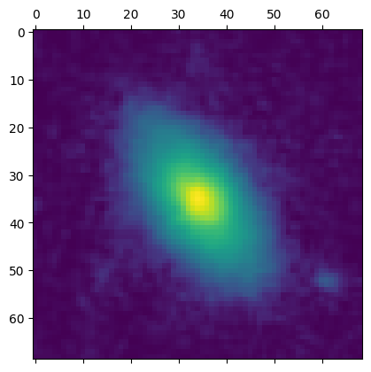

```python
plt.matshow(train_images_raw[0][:,:,0])
```

```python
print(train_labels[0])
```

```
[0. 0. 1. 0. 0.]
```

This dataset only includes Class 0, 1, 2, 4, and 7 from the galaxy10 dataset:

```
Galaxy10 dataset
├── *0* Class 0 (3461 images): Disk, Face-on, No Spiral
├── *1* Class 1 (6997 images): Smooth, Completely round
├── *2* Class 2 (6292 images): Smooth, in-between round
├── Class 3 (394 images): Smooth, Cigar shaped
├── *3* Class 4 (3060 images): Disk, Edge-on, Rounded Bulge
├── Class 5 (17 images): Disk, Edge-on, Boxy Bulge
├── Class 6 (1089 images): Disk, Edge-on, No Bulge
├── *4* Class 7 (1932 images): Disk, Face-on, Tight Spiral
├── Class 8 (1466 images): Disk, Face-on, Medium Spiral
└── Class 9 (1045 images): Disk, Face-on, Loose Spiral
```

[figure not shown]

Looking at the shape of the train_images_raw data:

```python
print(np.shape(train_images_raw))
```

```
(17457, 69, 69, 1)
```

To make it easier to feed into the neural network, reshape the data so instead of a tensor each image is a vector:

```python
train_images = train_images_raw.reshape(len(train_images_raw),69*69*1)/256.
test_images  = test_images_raw.reshape(len(test_images_raw),69*69*1)/256.
print(np.shape(train_images))
```

```
(17457, 4761)
```

### Neural Network

Next the neural network is going to take the input vector and output a classifcation vector, the 5 different types of galaxies.

The equation for how to do this is $v_{out} = 1.0/ \big( 1+\exp(-(W_2 \textrm{tanh}(W_1 v_{in} + b_1) +b_2))\big)$ where

- W1 is a size d x 4761 matrix
- W2 is a size 5 x d matrix
- b1 is a size d vector
- b2 is a size 5 vector

where d is the number of neurons in the network. let d =100

The last term: $1/(1+e^{-x})$ ensures that all the numbers in $v_{out}$ are between 0 and 1.

To make this function work in parallel on multiple $v_{in}$'s simultaneously, you can just supply them as a big matrix $V_{in}$ (of size `(17457, 4761)`) and add in some transpositions to make the matrix multiplication shapes work:

$$ v_{out} = \left(1+\exp\left[-\left(\left[W_2 \cdot \mathrm{tanh}(W_1 \cdot V_{in}^\top + b_1)^\top\right]^\top +b_2\right)^\top\right]\right)^{-1} $$

The output is going to give a value between 0 and 1 for each classification. The index with the greatest number will be the classification that the model predicts. We can make sure that our equation is right by calling the Neural Network, the answer will not be right as the network is not trained yet.

```python
d = 100
params = [
    0.1*np.random.randn(d,4761),
    0.1*np.random.randn(d),
    0.1*np.random.randn(5,d),
    0.1*np.random.randn(5)
]
def NeuralNetwork(params,imageVector):
   W1=params[0]
   b1=params[1]
   W2= params[2]
   b2 = params[3]
   h = jnp.tanh(W1 @ imageVector.T + b1).T
   power = -((W2@h).T + b2).T
   output = (1+jnp.exp(power))**(-1)
   return output

out = NeuralNetwork(params,train_images[3])
print("Model output: ", out)
print("Predicted Classification: ", np.argmax(out))
print("Actual Classification: ", np.argmax(train_labels[3]))
```

```
Model output:  [0.51634467 0.3356803  0.5999746  0.31575805 0.39565963]
Predicted Classification:  2
Actual Classification:  0
```

### Loss

Now we need to calculate the Loss to train the nueral network

To quantify the loss we can use cross entropy to calculate the difference between the predicted value of the classification and the actual value. The cross-entropy is defined as

$$ \sum_i -y_i \log(a_i) - (1-y_i)\log(1-a_i)$$

where $y_i$ is the $i'$th component of the exact label and $a_i$ is the $i'$th component of the label you get as output from the neural network.

So now for the image we looked at above we can now calculate the "loss" using the cross entropy:

```python
def loss(params, imageVector, correctLabel):
  y = correctLabel
  a = NeuralNetwork(params,imageVector)
  sum = 0
  for i in range(len(a)):
    sum += -y[i]*jnp.log(a[i])-(1-y[i])*jnp.log(1-a[i])
  return sum
crossentropy = loss(params,train_images[3],train_labels[3])
print(crossentropy)
```

```
2.869261
```

We can also create a function to find what percent the neural network is classifying correctly

```python
def fractionCorrect(params,images,labels):
  correct = 0
  for i in range(images.shape[0]):

    #classification vector
    out = NeuralNetwork(params,images[i])

    #the greatest index in the classification vector
    predicted = np.argmax(out)
    actual = np.argmax(labels[i])

    if (predicted == actual):
      correct +=1
  return correct/images.shape[0]
```

To make an objective function better, step the paramaters of the nework along the gradient. Jax can be used to get the gradient.

The gradient is `loss_grad = jit(jax.grad(jit(loss)))` and jit helps to speed up the calculation

# Testing the Model

To train the data:

- choose a random image in the **training** set.
- compute the gradient
- change the parameters by 0.1% of the gradient ( *learning rate* $\eta$)

Every 2000 steps we can check our model againt the test data to see how our neural network in imporving. Plotting the accuracy over time we can see how the model is improving ove time.

```python
params = [
    0.1*np.random.randn(d,4761),
    0.1*np.random.randn(d),
    0.1*np.random.randn(5,d),
    0.1*np.random.randn(5)
]


loss_grad = jit(jax.grad(jit(loss)))
accuracy = []
steps = 2000*100
for step in range(steps):
  i = np.random.randint(0, train_images.shape[0])
  gradient = loss_grad(params, train_images[i], train_labels[i])
  for j in range(len(params)):
    params[j] -= .001 * gradient[j]

  if(step %2000 == 0):
    percent = fractionCorrect(params, test_images, test_labels)
    accuracy.append(percent)
```

```
Final accuracy:  0.7238193018480493
```

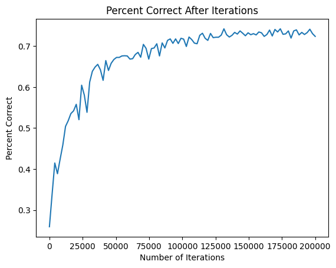

```python
x = np.linspace(0,2000*100,100)
print("Final accuracy: ",accuracy[-1])
plt.plot(x, accuracy)
plt.ylabel("Percent Correct")
plt.xlabel("Number of Iterations")
plt.title("Percent Correct After Iterations")
```

Since the neural network is returning a value for each classification, it would be interesting to see what percentage of the second highest prediction is correct for the incorrectly classified images:

```python
def fractionSecondCorrect(params,images,labels):
  correct = 0
  counter = 0
  for i in range(images.shape[0]):
    out = NeuralNetwork(params,images[i])
    predicted = np.argmax(out)
    actual = np.argmax(labels[i])
    if (predicted != actual):
      counter +=1
      out[predicted] = -np.inf
      if (np.argmax(out) == actual):
        correct +=1
  return correct/counter
percent = fractionCorrect(params, test_images, test_labels)
print(f"Percent wrong where the second max is correct: {percent*100}%")
```

[output not shown]

# Deep Neural Network

The neural network above is a shallow network as it only contains 1 hidden layer. To try and develop a better model we can use kerqas to implement a deep neural network.

```python
import numpy as np
import matplotlib.pyplot as plt
import pickle
import gzip
from tensorflow import keras
from tensorflow.keras import layers, models
from sklearn.model_selection import train_test_split
from tqdm.keras import TqdmCallback
```

Using keras we can implement an convolutional neural network to classify the galaxies. A benefit of a convolutional neural network is it preforms translation-invariant learning efficiently which will be beneficial for identifying galaxies that can be oriented in any direction.

Above we altered the image data into a vector, but for the convolutional neural network it will be optimal to keep the data in a 2d array.

```python
def load_data():
    with gzip.open("dataG.pkl.gz", 'rb') as f:
        train_images_raw, train_labels, test_images_raw, test_labels = pickle.load(f)

    #Adds a demention to represent the channel(needed for the CNN) and normalizes the data
    train_images = np.expand_dims(train_images_raw, axis=-1) / 255.0
    test_images = np.expand_dims(test_images_raw, axis=-1) / 255.0

    return train_images, train_labels, test_images, test_labels
```

### building the convolutional neural network

The model will be sepereated into 3 Convolutional blocks with the structure:

Conv2D → BatchNorm → Conv2D → MaxPooling

The goal is that each block can interpret different features. With the 32 filter block capturing features such as edges and gradients and as the filters increase, the scale of the features increases. So the 128 layer captures the galaxy shape as a feature. Using a Kernel size (3,3) allows for each point to be put into spatial context and interpret small details.

MaxPooling2D is used to reduce the dimenionality while preserving key features. So now when we apply the next convolitional block, the spatial context of each point is farther reaching in the image.

BatchNormalization stabilizes training by normalizing activations which reduces sensitivity to weight initialization

Then you flatten out the network into a vector and then reduce to the 5d vector output of galaxy classifications.

Finally, using a Keras optimizer to speed up the training time.

```python
def build_model():
    model = models.Sequential([
        layers.Conv2D(32, (3,3), activation='relu', input_shape=(69,69,1)),
        layers.BatchNormalization(),
        layers.Conv2D(32, (3,3), activation='relu'),
        layers.MaxPooling2D((2,2)),

        layers.Conv2D(64, (3,3), activation='relu'),
        layers.BatchNormalization(),
        layers.Conv2D(64, (3,3), activation='relu'),
        layers.MaxPooling2D((2,2)),

        layers.Conv2D(128, (3,3), activation='relu'),
        layers.BatchNormalization(),
        layers.Conv2D(128, (3,3), activation='relu'),
        layers.MaxPooling2D((2,2)),


        layers.Flatten(),
        layers.Dense(128, activation='relu'),
        layers.Dropout(0.3),
        layers.Dense(64, activation='relu'),
        layers.Dense(32, activation='relu'),
        layers.Dense(5, activation='softmax')
    ])

    #Keras Optimizer
    model.compile(optimizer=keras.optimizers.Adam(learning_rate=0.001),
                 loss='categorical_crossentropy',
                 metrics=['accuracy'])
    return model
```

[output not shown]

[output not shown]

[output not shown]

[output not shown]

[output not shown]

[output not shown]

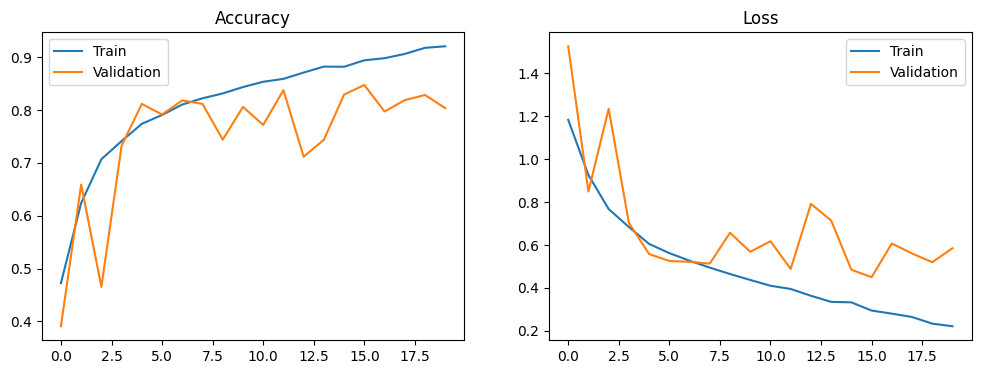

```
Test Accuracy: 0.8265
```

```python
def train(model, train_images, train_labels):
    #Create a validation set for training
    train_images, val_images, train_labels, val_labels = train_test_split(
        train_images, train_labels, test_size=0.2, random_state=42)

    #Using the validation set, we can make sure not to overfit by stopping early
    callbacks = [
        keras.callbacks.EarlyStopping(patience=5, restore_best_weights=True),
        TqdmCallback(verbose=1)
    ]

    #Training with mini batchs to increase the efficientcy of training the model
    history = model.fit(
        train_images, train_labels,
        batch_size=32,
        epochs=20,
        validation_data=(val_images, val_labels),
        callbacks=callbacks,
        verbose=0
    )
    return model, history



train_images, train_labels, test_images, test_labels = load_data()

model = build_model()

trained_model, history = train(model, train_images, train_labels)

plt.figure(figsize=(12,4))
plt.subplot(1,2,1)
plt.plot(history.history['accuracy'], label='Train')
plt.plot(history.history['val_accuracy'], label='Validation')
plt.title('Accuracy')
plt.legend()

plt.subplot(1,2,2)
plt.plot(history.history['loss'], label='Train')
plt.plot(history.history['val_loss'], label='Validation')
plt.title('Loss')
plt.legend()
plt.show()


test_loss, test_acc = trained_model.evaluate(test_images, test_labels, verbose=0)
print(f"\nTest Accuracy: {test_acc:.4f}")
```

```python
from google.colab import drive
drive.mount('/content/drive')
```